# genreNetwork

Clint McKenna

October 22, 2019

## data prep

```r
# load packages
library(igraph)
library(tidyverse)
# functions
select <- dplyr::select

# read in data
movies <- read.csv('../data/clean/movies.csv')
genres <- read.csv('../data/clean/genres.csv')


# get actors from highest budget movies
top <- movies %>%
  select(title, budget) %>%
  #group_by(title) %>%
  top_n(n = 100, wt = budget)
genres <- left_join(top, genres, by = 'title')
```

## reshape genre column

Let’s take a look at how the genre column looks. We can preview the first few rows using the head() function.

```r
head(genres)
```

```
##                                      title    budget X    id
## 1                                   Avatar 237000000 1 19995
## 2                                   Avatar 237000000 2 19995
## 3                                   Avatar 237000000 3 19995
## 4                                   Avatar 237000000 4 19995
## 5 Pirates of the Caribbean: At World's End 300000000 5   285
## 6 Pirates of the Caribbean: At World's End 300000000 6   285
##             genre
## 1          Action
## 2       Adventure
## 3         Fantasy
## 4 Science Fiction
## 5       Adventure
## 6         Fantasy
```

Right now, the data is in “long” format. There is one row for each genre. If a movie has multiple genres, it has one row for each. The first entry, Avatar, has 4: Action, Adventure, Fantasy, and Science Fiction.

How can we reshape the data for network visualization? There are a usually a couple ways that network data is structured: an adjacency matrix and an edge list. For this task, we will focus on an edge list, just because I find that more intuitive.

An edge list has two columns. You can think of each row as a pair of nodes in a network that share an edge of some sort. In this case, it if they both occur in a movie. If we just look at the first movie above, we want a edge list that looks like this:

Action, Adventure Action, Fantasy Action, Science Fiction Adventure, Fantasy Adventure, Science Fiction Fantasy, Science Fiction

To illustrate things, lets just start with the movie Avatar. We can filter using the filter() function from tidyverse.

```r
# filter only Avatar
dat <- genres %>%
  filter(title == 'Avatar')

# preview
head(dat)
```

```
##    title    budget X    id           genre
## 1 Avatar 237000000 1 19995          Action
## 2 Avatar 237000000 2 19995       Adventure
## 3 Avatar 237000000 3 19995         Fantasy
## 4 Avatar 237000000 4 19995 Science Fiction
```

Matching up the genres can be accomplished by using the combn() function, along with some cleanup.

```r
# check possible combinations of genre column
# t() will transpose the matrix that is output (flip sideways)
combinations <- combn(dat$genre, m = 2) %>%
  t()

combinations
```

```
##      [,1]      [,2]
## [1,] Action    Adventure
## [2,] Action    Fantasy
## [3,] Action    Science Fiction
## [4,] Adventure Fantasy
## [5,] Adventure Science Fiction
## [6,] Fantasy   Science Fiction
## 20 Levels: Action Adventure Animation Comedy Crime Documentary ... Western
```

So for each movie, we will create a dataframe from the output of this matrix. Like so…

```r
data.frame(
  genre1 = combinations[,1],
  genre2 = combinations[,2]
)
```

```
##      genre1          genre2
## 1    Action       Adventure
## 2    Action         Fantasy
## 3    Action Science Fiction
## 4 Adventure         Fantasy
## 5 Adventure Science Fiction
## 6   Fantasy Science Fiction
```

So let’s write a function to get the combinations we are looking for.

```r
# function for acquiring genre combinations
# x will be the input for the fuction - the dataframe we are using
getCombinations <- function(x) {

  # the column we are looking to make into an edge list is in quotes
  input <- x[,'genre']

  # here, we make a new object within our function for possible combinations
  combinations <- combn(input, m = 2) %>%
  t()

  # and output a dataframe, which is returned when function is run
  output <- data.frame(
    genre1 = combinations[,1],
    genre2 = combinations[,2]
  )

  return(output)
  rm(combinations, output)
}
```

```r
# remove films that only have one genre (one row in dataframe)
# here, we group by individual movies, add a column for the genre count
# then, filter out movies where count is 1 or less
genreList <- genres %>%
  group_by(title) %>%
  mutate(count = n()) %>%
  filter(count > 1) %>%
  select(-count) %>%
  ungroup() %>%
  mutate_all(as.character) %>%
  as.data.frame()

# use split to split up dataframe into individual lists for each movie
genreList <- genreList %>%
  # mutate(group = group_indices(., title)) %>%
  # split(.$group) %>%
  # map_dfr(getCombinations, .id = 'group')
  split(.$title) %>%
  map_dfr(getCombinations, .id = 'title')
```

[output not shown]

[output cut: 520 more lines]

[output not shown]

Now, let’s preview edgelist.

```r
# preview
head(genreList)
```

```
##      title    genre1          genre2
## 1     2012    Action       Adventure
## 2     2012    Action Science Fiction
## 3     2012 Adventure Science Fiction
## 4 47 Ronin     Drama          Action
## 5 47 Ronin     Drama       Adventure
## 6 47 Ronin     Drama         Fantasy
```

```r
tail(genreList)
```

```
##                     title          genre1          genre2
## 404 X-Men: The Last Stand       Adventure          Action
## 405 X-Men: The Last Stand       Adventure Science Fiction
## 406 X-Men: The Last Stand       Adventure        Thriller
## 407 X-Men: The Last Stand          Action Science Fiction
## 408 X-Men: The Last Stand          Action        Thriller
## 409 X-Men: The Last Stand Science Fiction        Thriller
```

```r
genres %>%
  filter(title == 'Zulu')
```

```
## [1] title  budget X      id     genre
## <0 rows> (or 0-length row.names)
```

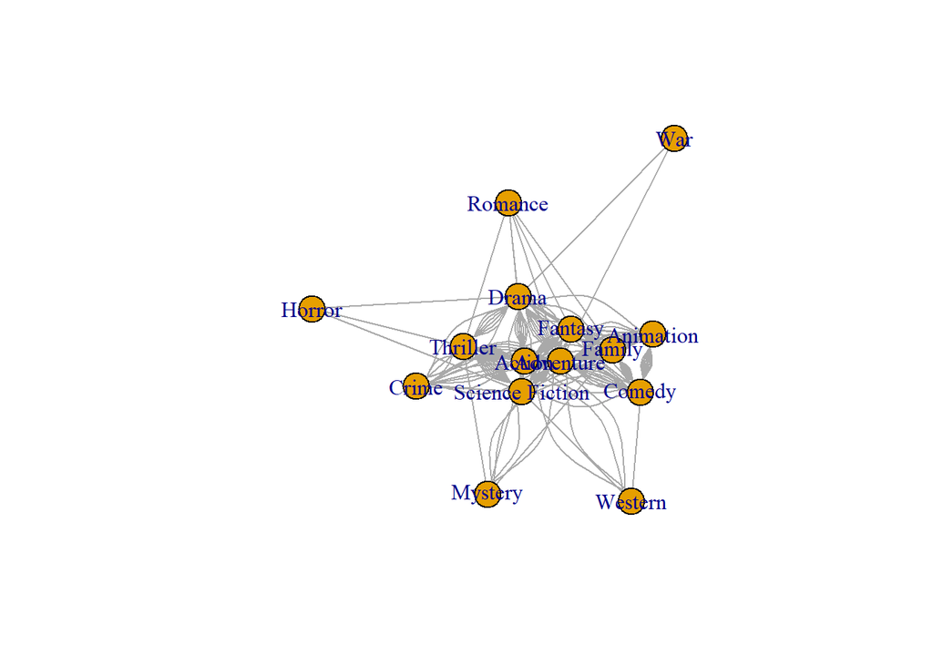

```r
# for the next steps, we need to move title to the last column
genreList <- genreList %>%
  select(genre1, genre2, title)

# create network object. non-directed
net <- graph_from_data_frame(
  genreList,
  directed = FALSE
)

# plot
plot(net)
```

Add edge weights

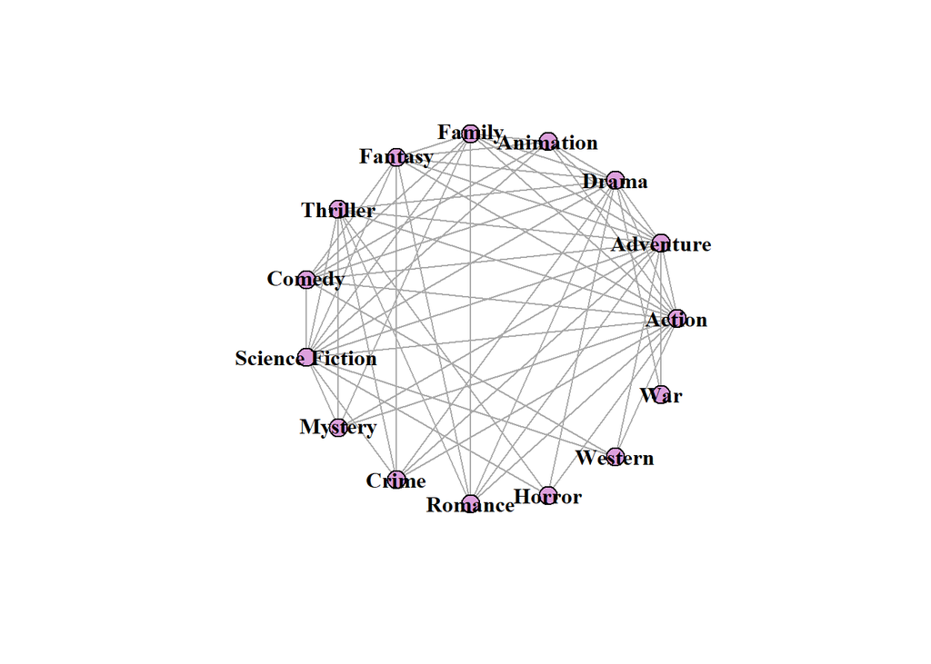

```r
net2 <- graph.adjacency(get.adjacency(net),weighted=TRUE)
net2 <- as.undirected(net2)

plot(net2,
     layout = layout_in_circle,
     # layout = layout_nicely,
     # vertex.label.cex=0.75,
     vertex.label.font=2,
     vertex.label.color='black',
     # vertex.label = NA,
     vertex.shape='circle',
     vertex.size = 10,
     vertex.color = 'plum',
     edge.width = 1)
```

## degree centrality

degree is a count of the number of neighbors a node has

Betweenness centrality measures the extent to which a vertex lies on paths between other vertices.

$\displaystyle{b_i = \sum_{s, t} w_{s,t}^{i} = \sum_{s, t} \frac{n_{s,t}^{i}}{n_{s,t}}}$

```r
degree(net2)
```

```
##          Action       Adventure           Drama       Animation
##              13              13              12               7
##          Family         Fantasy        Thriller          Comedy
##               9               9               8               8
## Science Fiction         Mystery           Crime         Romance
##              12               5               6               6
##          Horror         Western             War
##               4               4               2
```

```r
betweenness(net2)
```

```
##          Action       Adventure           Drama       Animation
##        5.391667        4.000000       18.741667        0.000000
##          Family         Fantasy        Thriller          Comedy
##        1.191667        3.033333        3.183333        1.833333
## Science Fiction         Mystery           Crime         Romance
##       17.583333        1.666667        3.450000       24.641667
##          Horror         Western             War
##       10.916667        3.333333        1.333333
```

```r
eigen_centrality(net2)$vector
```

```
##          Action       Adventure           Drama       Animation
##      0.92959320      1.00000000      0.19447958      0.21582740
##          Family         Fantasy        Thriller          Comedy
##      0.35148648      0.60365351      0.27103215      0.18829171
## Science Fiction         Mystery           Crime         Romance
##      0.66434916      0.04344118      0.09005449      0.02981853
##          Horror         Western             War
##      0.01832997      0.04193716      0.01063135
```

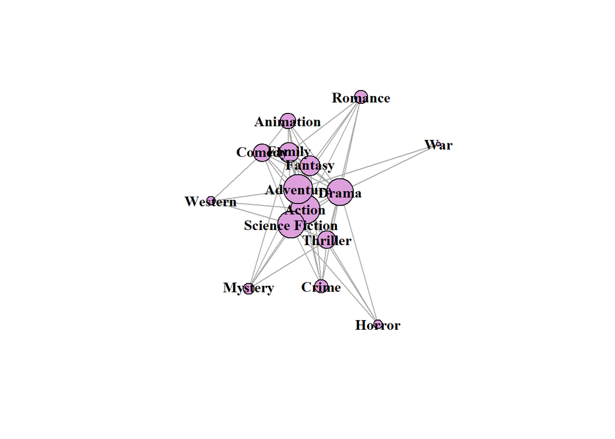

```r
plot(net2,
     # layout = layout_in_circle,
     layout = layout_nicely,
     # vertex.label.cex=0.75,
     vertex.label.font=2,
     vertex.label.color='black',
     # vertex.label = NA,
     vertex.shape='circle',
     vertex.size = degree(net2)*2,
     vertex.color = 'plum',
     edge.width = 1)
```